# An extremely short introduction to ggplot

Michael Hahsler

2021-02-25

## Introduction to ggplot2

The package `ggplot2` implements the ideas introduced by Leland Wilkinson in the book [The Grammar of Graphics](https://www.springer.com/statistics/computational/book/978-0-387-24544-7). The idea is that every graph is built from the same basic components:

- Data
- Variable transformations (e.g., counting)
- Scale transformations (e.g., a linear or a log scale, color scales)
- Coordinate system (default is Cartesian coordinates)
- Elements: graphs (e.g., points) and their aesthetic attributes (e.g., color)
- Guides (e.g., axes and legends)

In `ggplot2`, the components are combined using the `+` operator.

> `ggplot(data, mapping = aes(x = ..., y = ..., color = ...)) +` `geom_point()`

`...` are column names in the `data.frame` or `tibble` `data`. Each `geom_X` defines an element and uses a `stat_Y` function (variable transformation) to calculate what is visualizes. For example, `geom_bar` uses `stat_count` to create a bar chart by counting how often each value appears in the data (see `? geom_bar`). `geom_point` just uses the stat `"identity"` to display the points using the coordinates as they are. Scales, the coordinate system and guides are added automatically and can be changed by adding them as a new component to the end of the call.

RStudio’s [Data Visualization Cheat Sheet](https://github.com/rstudio/cheatsheets/raw/master/data-visualization-2.1.pdf) offers a comprehensive overview of available components. A good introduction can be found in the [Chapter on Data Visualization](https://r4ds.had.co.nz/data-visualisation.html) of the free book [R for Data Science](https://r4ds.had.co.nz).

## Plots

```r
library(tidyverse)
data(iris)
iris <- as_tibble(iris)
iris
```

```
## # A tibble: 150 x 5
##    Sepal.Length Sepal.Width Petal.Length Petal.Width Species
##           <dbl>       <dbl>        <dbl>       <dbl> <fct>
##  1          5.1         3.5          1.4         0.2 setosa
##  2          4.9         3            1.4         0.2 setosa
##  3          4.7         3.2          1.3         0.2 setosa
##  4          4.6         3.1          1.5         0.2 setosa
##  5          5           3.6          1.4         0.2 setosa
##  6          5.4         3.9          1.7         0.4 setosa
##  7          4.6         3.4          1.4         0.3 setosa
##  8          5           3.4          1.5         0.2 setosa
##  9          4.4         2.9          1.4         0.2 setosa
## 10          4.9         3.1          1.5         0.1 setosa
## # … with 140 more rows
```

### Scatterplot

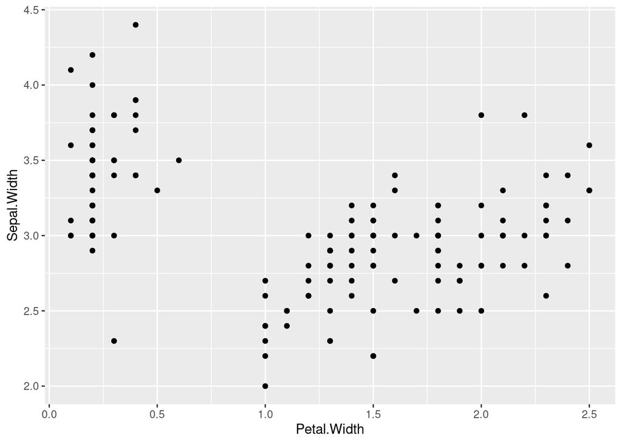

```r
ggplot(iris, aes(x = Petal.Width, y = Sepal.Width)) + geom_point()
```

Color by species

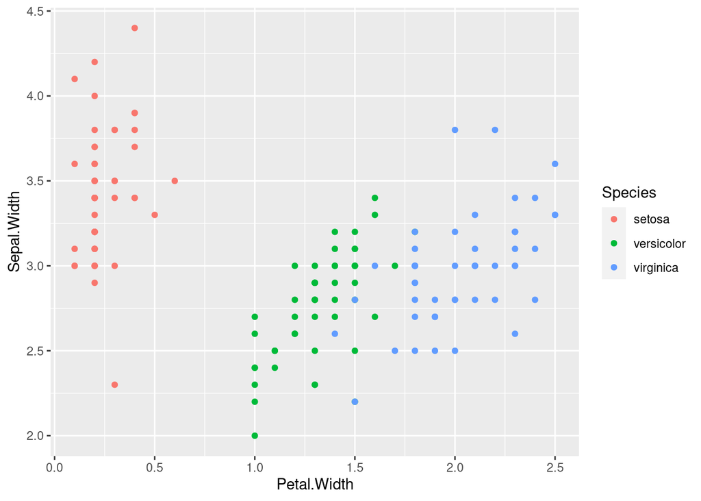

```r
ggplot(iris, aes(x = Petal.Width, y = Sepal.Width, color = Species)) + geom_point()
```

### Histogram

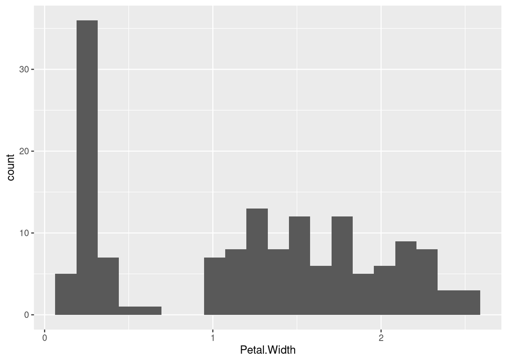

```r
ggplot(iris, aes(Petal.Width)) + geom_histogram(bins = 20)
```

Color by species

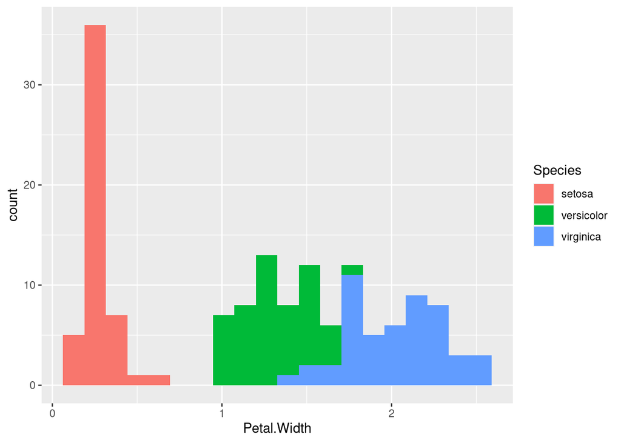

```r
ggplot(iris, aes(Petal.Width, fill = Species)) + geom_histogram(bins = 20)
```

Density instead of counts

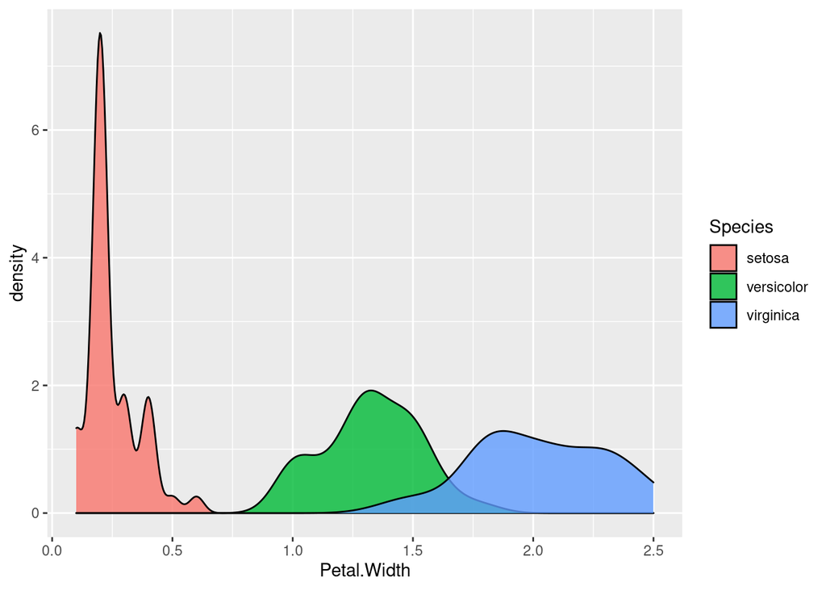

```r
ggplot(iris, aes(Petal.Width, fill = Species)) + geom_density(alpha = .8)
```

### Barplot

Barplots count! Each `geom_` has a `stat_` associates. `geom_bar` uses `stat_count` (see `? geom_bar`).

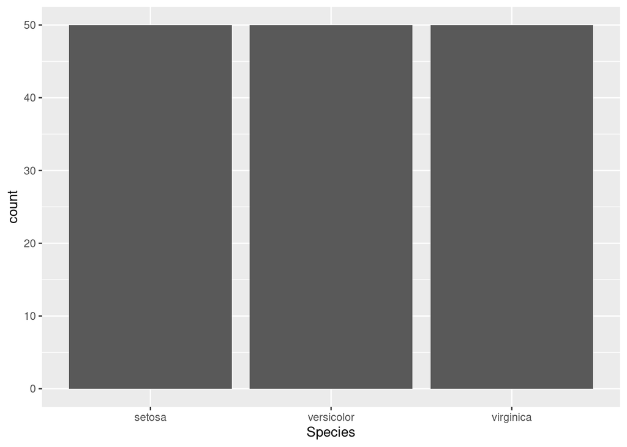

```r
ggplot(iris, aes(Species)) + geom_bar()
```

### Boxplot

```r
iris_long <- iris %>% mutate(id = row_number()) %>% pivot_longer(1:4)

iris_long
```

```
## # A tibble: 600 x 4
##    Species    id name         value
##    <fct>   <int> <chr>        <dbl>
##  1 setosa      1 Sepal.Length   5.1
##  2 setosa      1 Sepal.Width    3.5
##  3 setosa      1 Petal.Length   1.4
##  4 setosa      1 Petal.Width    0.2
##  5 setosa      2 Sepal.Length   4.9
##  6 setosa      2 Sepal.Width    3
##  7 setosa      2 Petal.Length   1.4
##  8 setosa      2 Petal.Width    0.2
##  9 setosa      3 Sepal.Length   4.7
## 10 setosa      3 Sepal.Width    3.2
## # … with 590 more rows
```

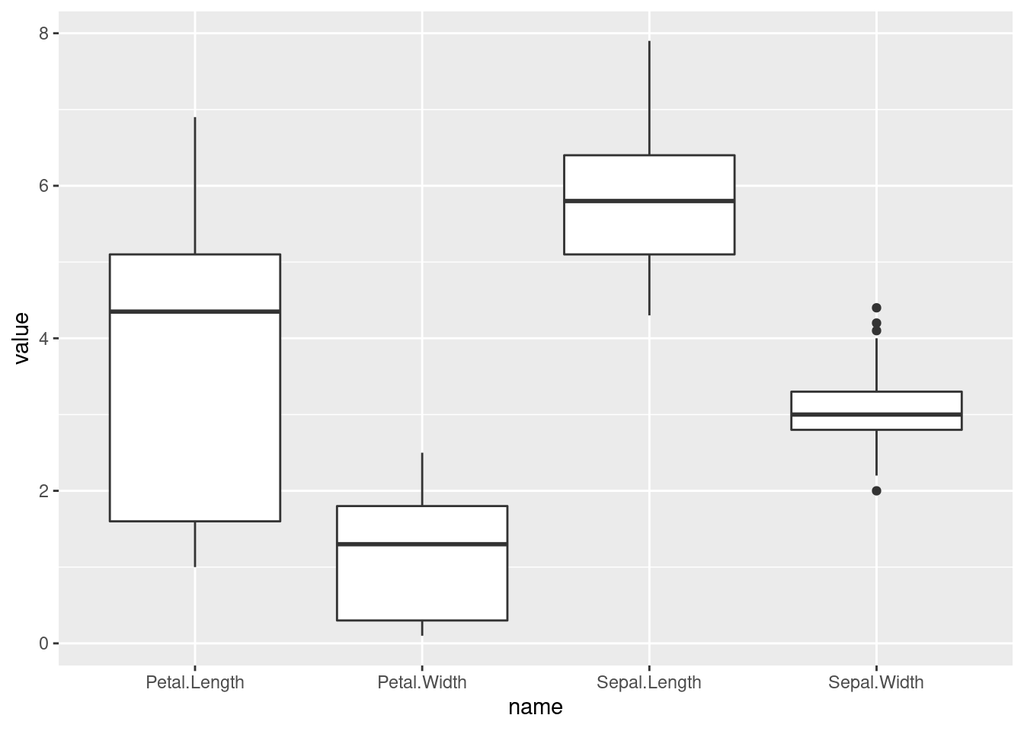

```r
ggplot(iris_long, aes(name, value)) + geom_boxplot()
```

## Colors and Themes

Everything that changes with the data needs to go in the `aes()` in `ggplot()`. For example, do not put color into `geom_point()` unless you want all point having the same color.

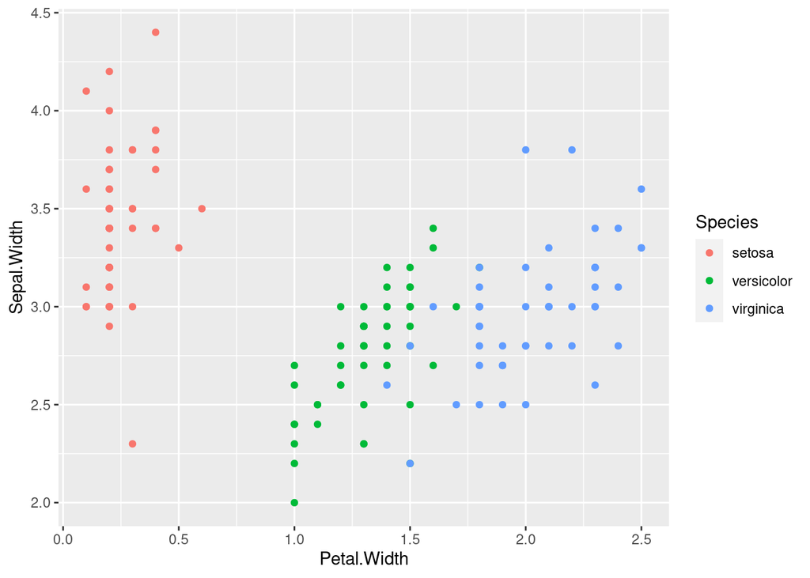

```r
ggplot(iris, aes(x = Petal.Width, y = Sepal.Width, color = Species)) + geom_point()
```

Use a different color scheme

```r
library(viridis)
```

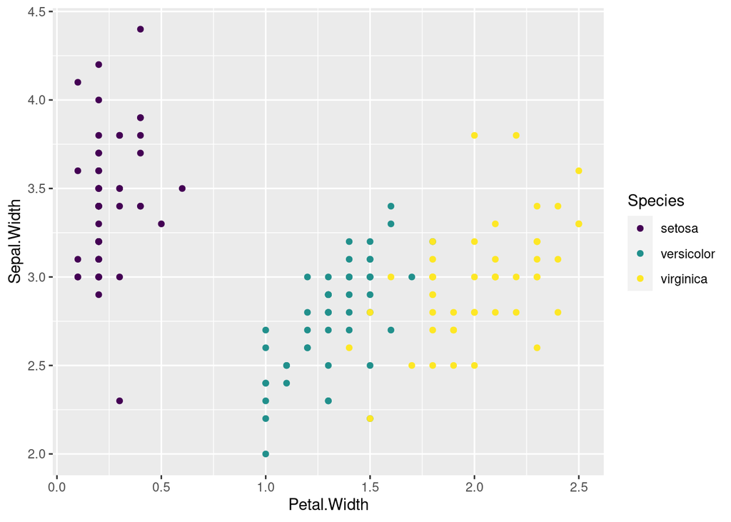

```r
ggplot(iris, aes(x = Petal.Width, y = Sepal.Width, color = Species)) + geom_point() +
  scale_color_viridis(discrete=TRUE)
```

You need to distinguish between discrete (for factors) and continuous scales. You can apply scales to color and fill (i.e, `scale_color_*` and `scale_fill_*`).

Themes let you change the look of your plots.

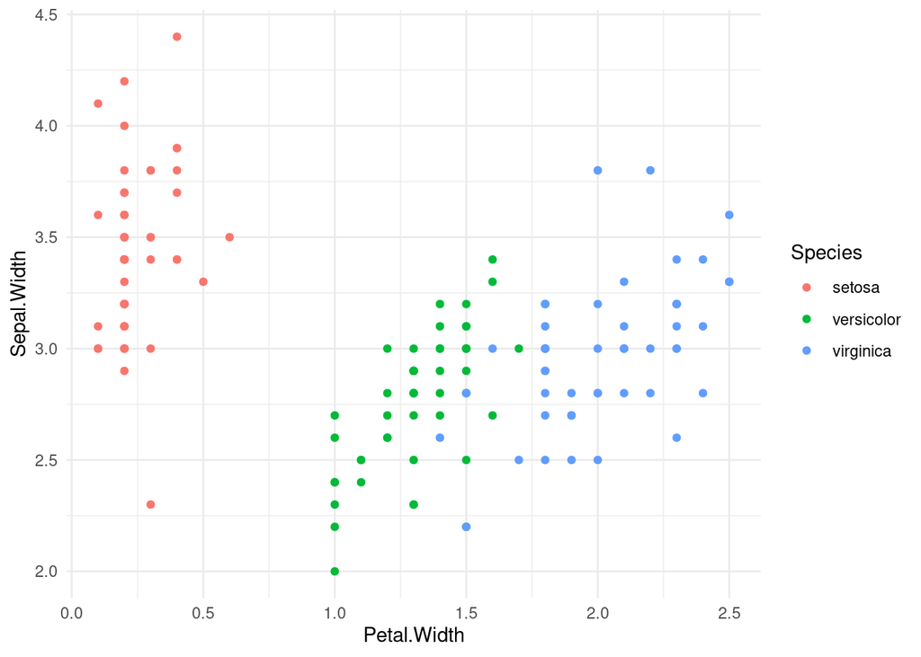

```r
ggplot(iris, aes(x = Petal.Width, y = Sepal.Width, color = Species)) + geom_point() +
  theme_minimal()
```

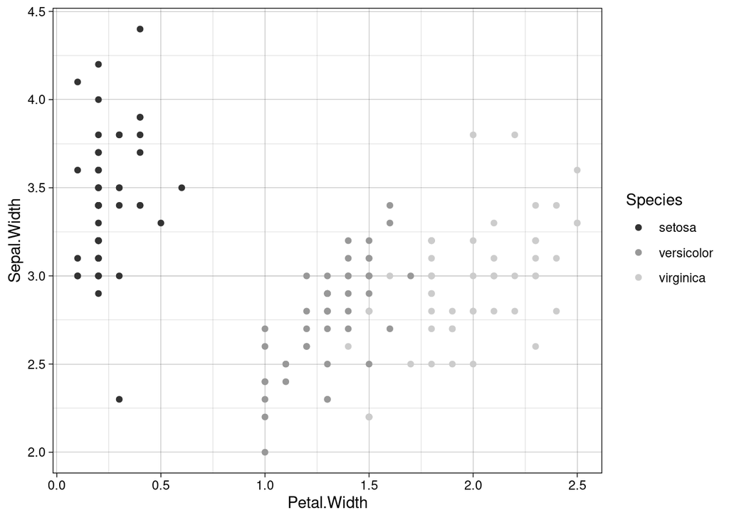

```r
ggplot(iris, aes(x = Petal.Width, y = Sepal.Width, color = Species)) + geom_point() +
  theme_linedraw() + scale_color_grey()
```

## Facets

Group plot by a discrete variable

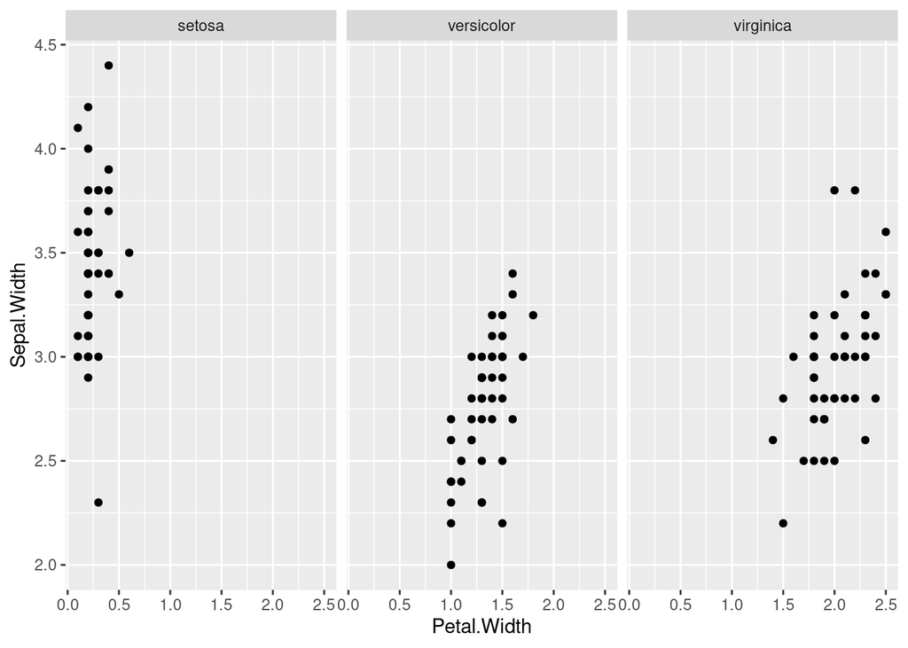

```r
ggplot(iris, aes(x = Petal.Width, y = Sepal.Width)) + geom_point() +
  facet_grid(cols = vars(Species))
```